# GGally Parameter Test

Keyan Huang

2022-11-15

## Environment Preparation

**Dataset `iris` will be used as source for `ggpairs` plotting.**

Note: `iris` is a dataset included in base-R.

```r
library("tidyverse")
library("GGally")
theme_set(theme_bw(base_size = 15) + theme(legend.position="bottom"))

## For readability, the dataset 'iris' is saved to variable 'data'
data <- tibble(iris)
head(iris)
```

```
##   Sepal.Length Sepal.Width Petal.Length Petal.Width Species
## 1          5.1         3.5          1.4         0.2  setosa
## 2          4.9         3.0          1.4         0.2  setosa
## 3          4.7         3.2          1.3         0.2  setosa
## 4          4.6         3.1          1.5         0.2  setosa
## 5          5.0         3.6          1.4         0.2  setosa
## 6          5.4         3.9          1.7         0.4  setosa
```

## Trials of GGpairs Parameters

**For R-documentation, see [ggpairs: ggpairs - A ggplot2 generalized pairs plot](https://www.rdocumentation.org/packages/GGally/versions/1.5.0/topics/ggpairs)**

1. Standard usage from Singmann’s lectures

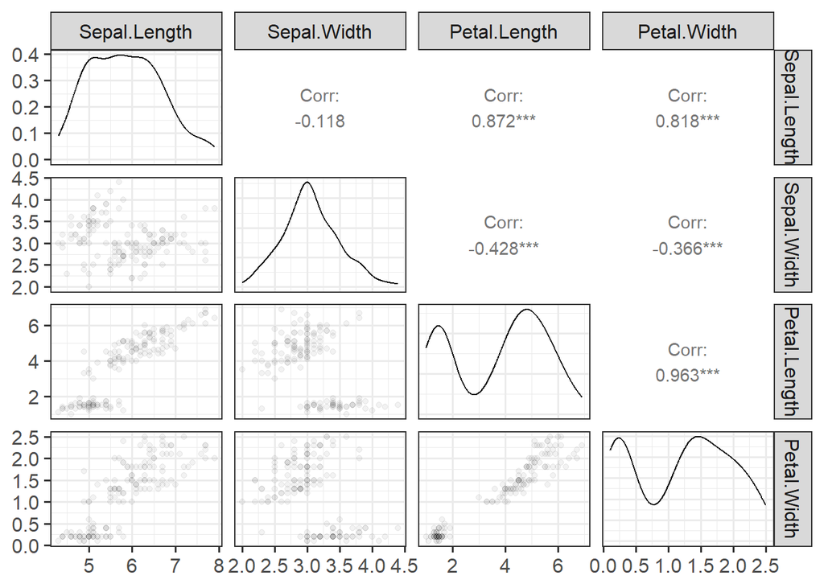

```r
ggpairs(data, columns = 1:4, lower = list(continuous = wrap("points", alpha = 0.05)))
```

2. Change `lower` to `upper`

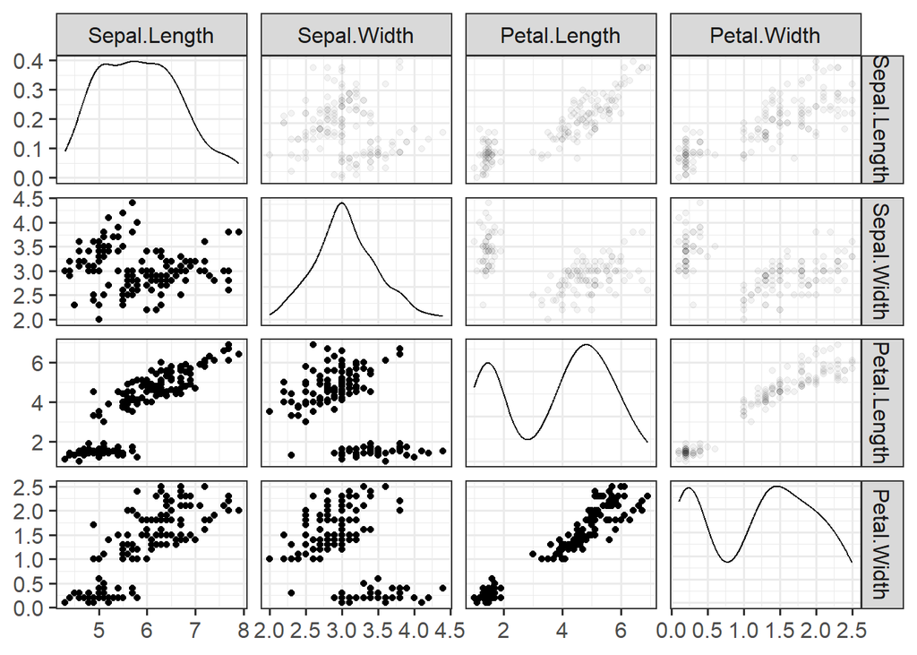

```r
ggpairs(data, columns = 1:4, upper = list(continuous = wrap("points", alpha = 0.05)))
```

3. Combine `lower` and `upper`, and adjust other parameters to discriminate between `upper` and `lower`

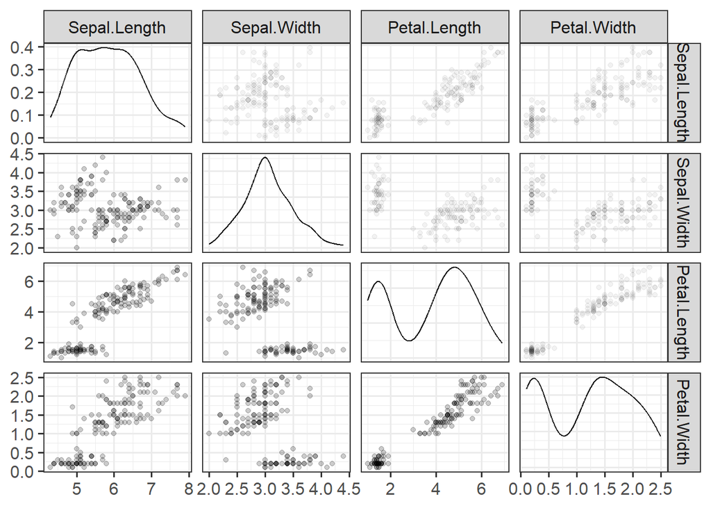

```r
## lower alpha = 0.2, upper alpha = 0.05
ggpairs(data, columns = 1:4, lower = list(continuous = wrap("points", alpha = 0.2)), upper = list(continuous = wrap("points", alpha = 0.05)))
```

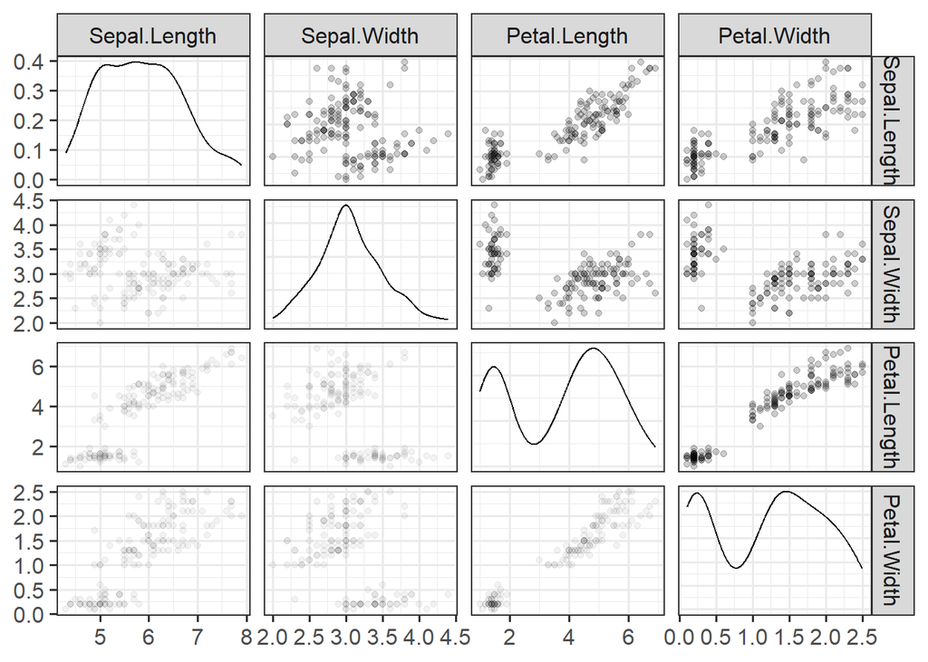

```r
## lower alpha = 0.05, upper alpha = 0.2
ggpairs(data, columns = 1:4, lower = list(continuous = wrap("points", alpha = 0.05)), upper = list(continuous = wrap("points", alpha = 0.2)))
```

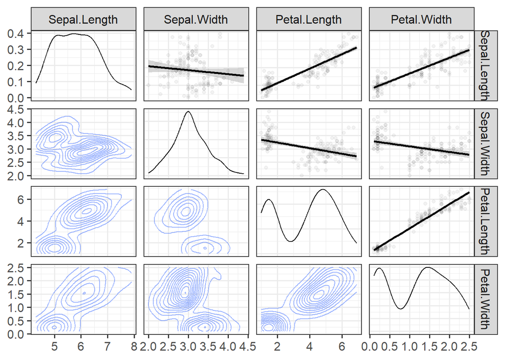

```r
## lower "density" (alpha = 0.5), upper "smooth"
ggpairs(data, columns = 1:4, lower = list(continuous = wrap("density", alpha = 0.5)), upper = list(continuous = wrap("smooth", alpha = 0.05)))
```

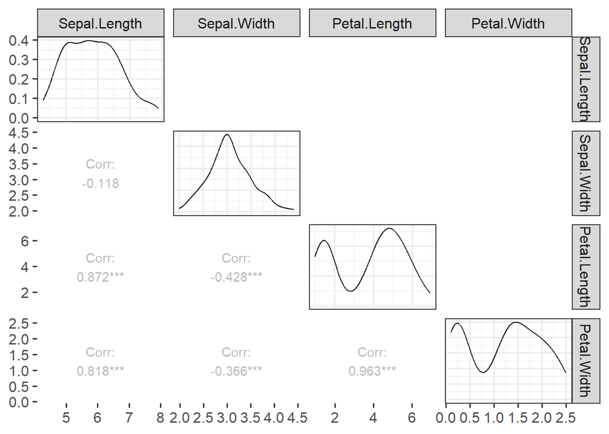

```r
## lower "cor" (alpha =), upper "blank"
ggpairs(data, columns = 1:4, lower = list(continuous = wrap("cor", alpha = 0.5)), upper = list(continuous = wrap("blank", alpha = 0.05)))
```

> Based on 2 & 3, `upper` and `lower` probably define respectively the plot properties on the upper-right and the lower-left; if `lower` is not explicitly defined (as in 2), it will be set as `list(continuous = wrap("points", alpha = 1))`, which draws an intransparent scatterplot; if `upper` is not explicitly defined (as in 1), it will be set as `list(continuous = wrap("cor", alpha = 1))`, which shows the correlation coefficients.
4. Change `continuous` to `combo` using columns from 3 to 5 (only 5th column `Species` is categorical so `discrete` cannot be used)

Note: `continuous` is for continuous DV & IV, `combo` is for one continuous variable and one categorical variable, `discrete` is for categorical DV & IV.

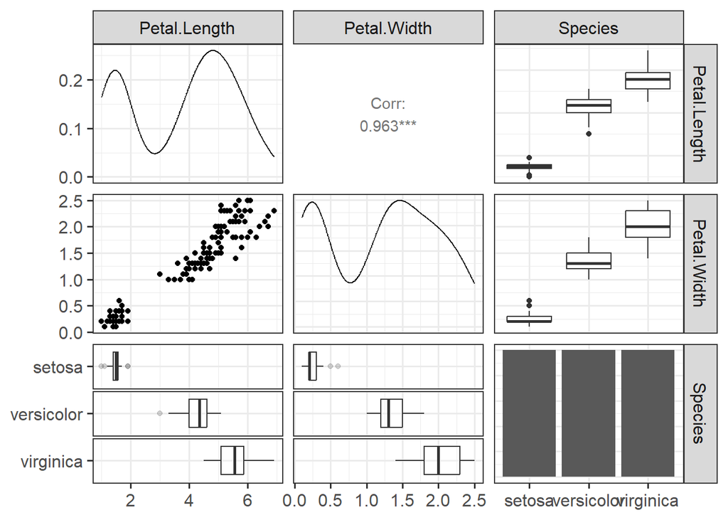

```r
## alpha = 0.2
## using option "box"
ggpairs(data, columns = 3:5, lower = list(combo = wrap("box", alpha = 0.2)))
```

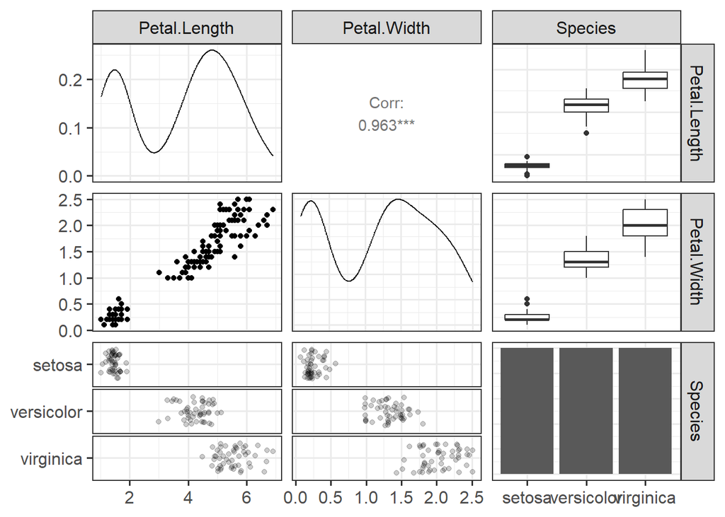

```r
## using option "dot"
ggpairs(data, columns = 3:5, lower = list(combo = wrap("dot", alpha = 0.2)))
```

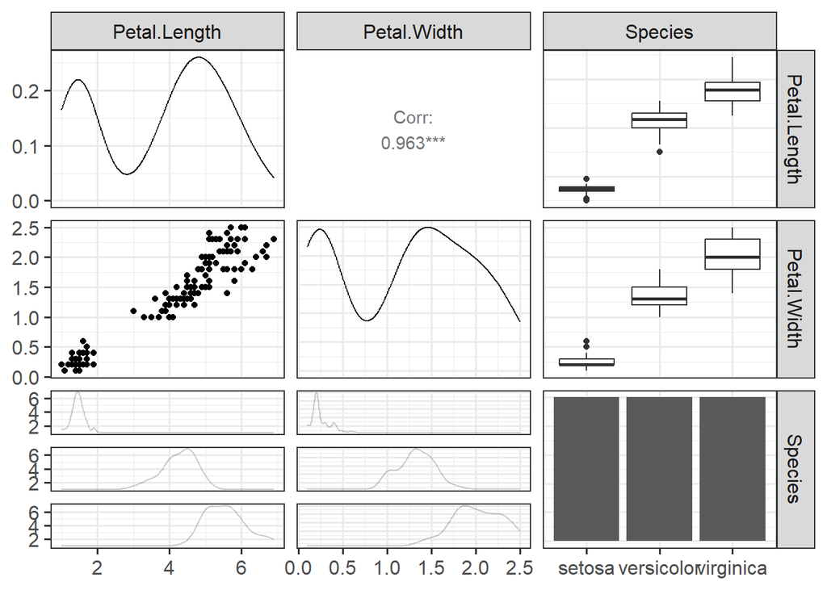

```r
## using option "facetdensity"
ggpairs(data, columns = 3:5, lower = list(combo = wrap("facetdensity", alpha = 0.2)))
```

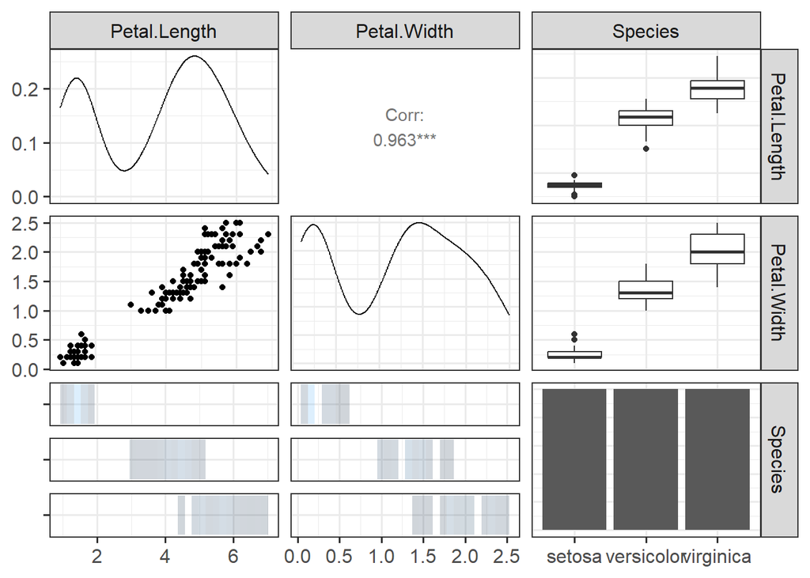

```r
## using option "denstrip"
ggpairs(data, columns = 3:5, lower = list(combo = wrap("denstrip", alpha = 0.2)))
```

5. Combine `continuous` and `combo` using columns from 3 to 5

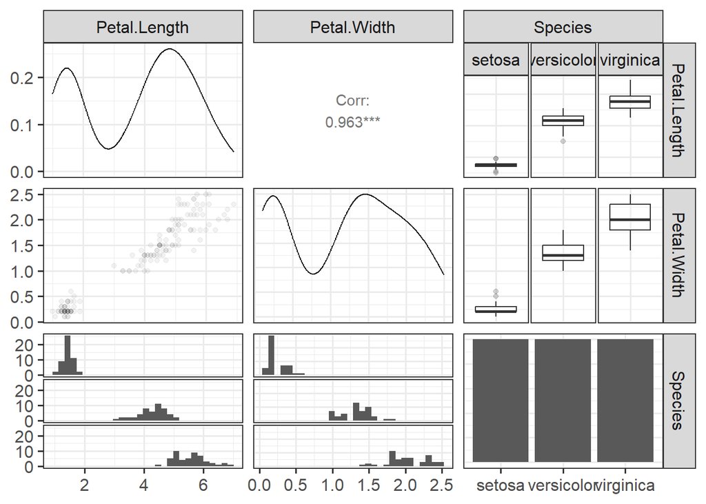

```r
## alpha = 0.2
## place 'continuous' and 'combo' ('box') in different places
ggpairs(data, columns = 3:5, lower = list(continuous = wrap("points", alpha = 0.05)), upper = list(combo = wrap("box", alpha = 0.2)))
```

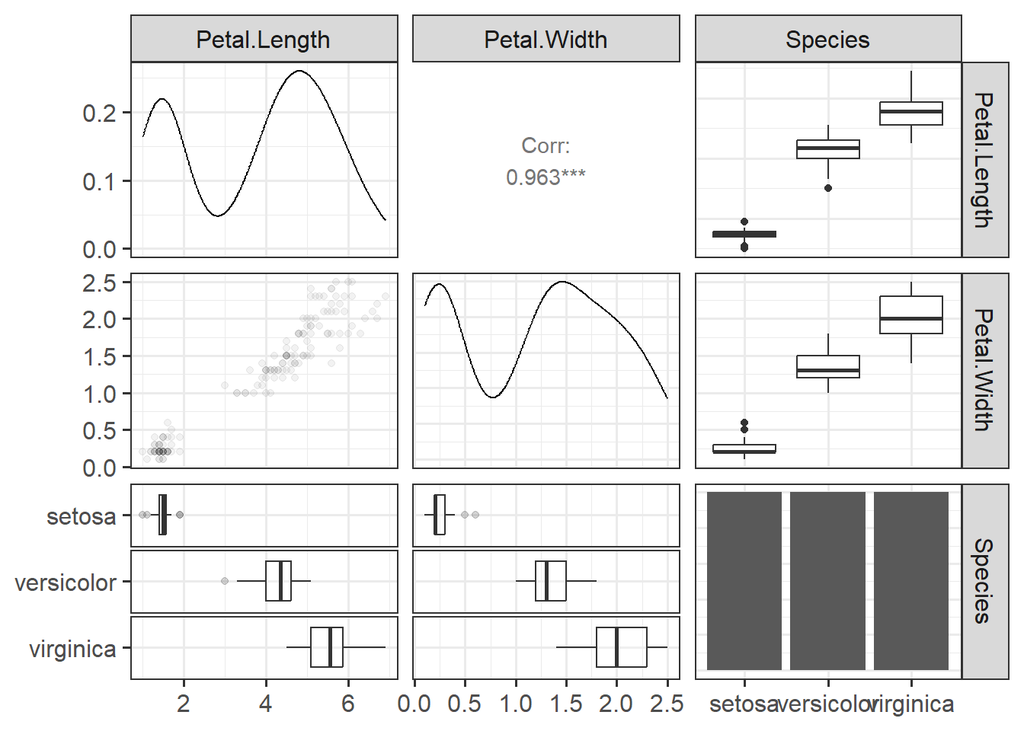

```r
## place 'continuous' and 'combo' in one place ('lower')
ggpairs(data, columns = 3:5, lower = list(continuous = wrap("points", alpha = 0.05), combo = wrap("box", alpha = 0.2)))
```

6. Place `continuous` and `combo` out of `wrap()` (and thus there will be no `alpha`)

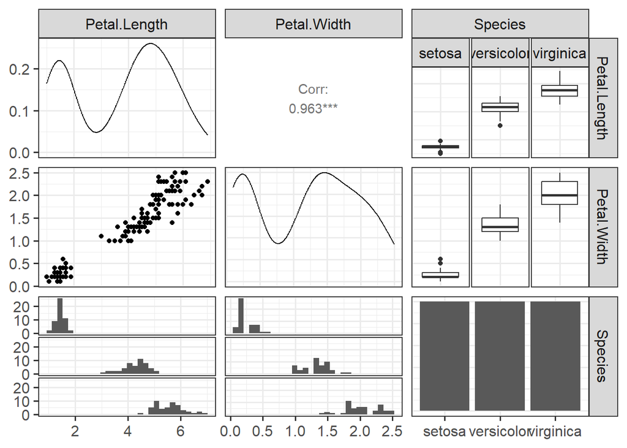

```r
## place 'continuous' and 'combo' ('box') in different places
ggpairs(data, columns = 3:5, lower = list(continuous = "points"), upper = list(combo = "box"))
```

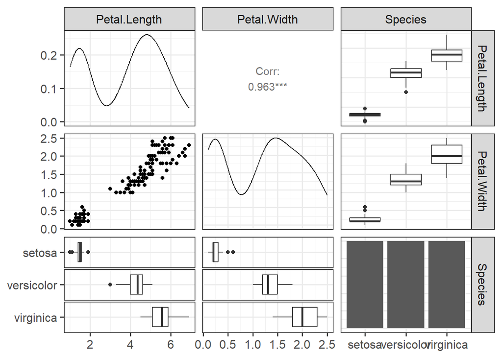

```r
## place 'continuous' and 'combo' in one place ('lower')
ggpairs(data, columns = 3:5, lower = list(continuous = "points", combo = "box"))
```

> Based on 4 & 5, `continuous`, `combo` and `discrete` are probably different approaches of wrapping-up the data before final plotting; by placing them after function `wrap()`, we are able to adjust the graphic properties (e.g. transparency by `alpha`) of the sub-plots.

**This is the end of the document.**